# Assignment 1

```r
print("Total no paths")
```

```
## [1] "Total no paths"
```

```r
print(no_walk)
```

```
## [1] 118
```

```r
print("These no-walks are directed")
```

```
## [1] "These no-walks are directed"
```

5. The network-level measure of degree centrality is a good indicator of the dispersion of the degree distribution in a network. Generate and plot a network in R in which the network-level measure of degree centrality, is equal to 1, and another where it is equal to 0. Would this relationship hold true for these networks for other measures of centrality, such as closeness or betweenness?

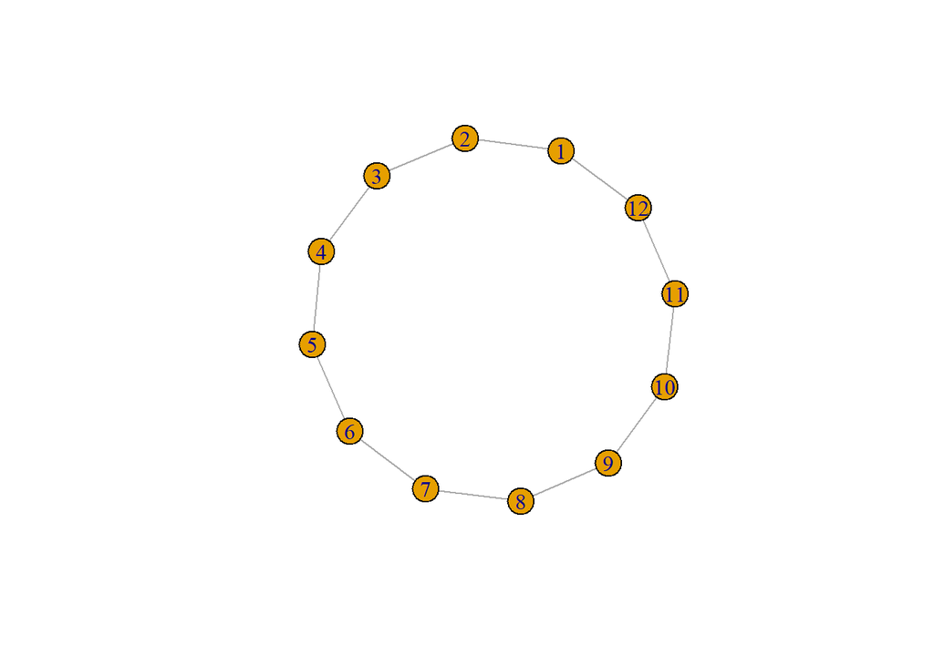

```r
#Network with level measure of degree centrality = 0
graph1 <-  graph.ring(12,directed=FALSE)
plot(graph1)
```

```r
graph1_degree <- degree(graph1)
graph1_degree  <- as.data.frame(graph1_degree)
Centrality_0 <-sum(max(graph1_degree)-graph1_degree)/((12-1)*(12-2))
print("Network Measure of Degree Centrality")
```

```
## [1] "Network Measure of Degree Centrality"
```

```r
Centrality_0
```

```
## [1] 0
```

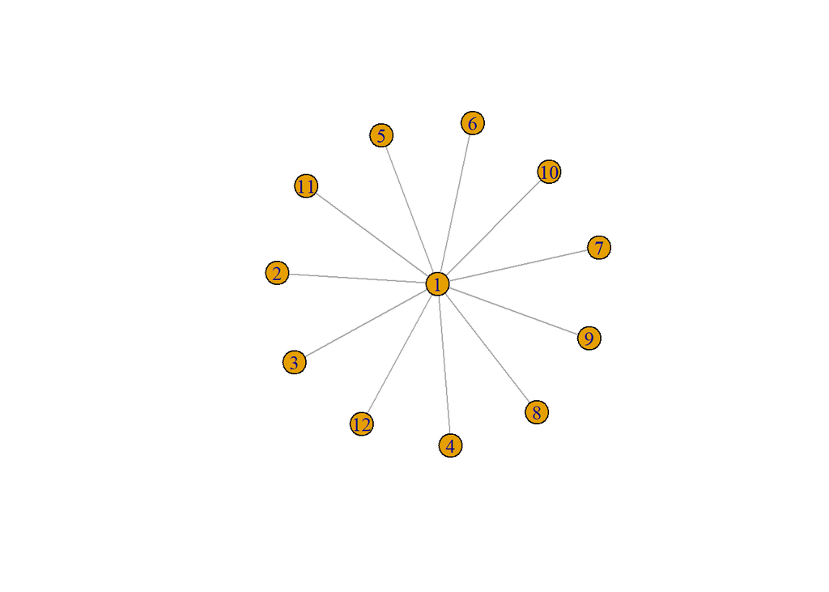

```r
#0

#Network with level measure of degree centrality = 1
graph2 <-  graph.star(12, mode="undirected")
plot(graph2)
```

```r
graph2_degree <- degree(graph2)
graph2_degree  <- as.data.frame(graph2_degree)
Centrality_1 <-sum(max(graph2_degree)-graph2_degree)/((12-1)*(12-2))
print("Network Measure of Degree Centrality")
```

```
## [1] "Network Measure of Degree Centrality"
```

```r
Centrality_1
```

```
## [1] 1
```

```r
#1

#Closeness of network with level measure of degree centrality = 0
graph1_closeness <- closeness(graph1)
graph1_closeness  <- as.data.frame(graph1_closeness)
Closeness_0 <- sum(max(graph1_closeness)-graph1_closeness)/((12-1)*(12-2))
print("Network Measure of Closeness for centrality = 0")
```

```
## [1] "Network Measure of Closeness for centrality = 0"
```

```r
print(Closeness_0)
```

```
## [1] 0
```

```r
#0

#Closeness of network with level measure of degree centrality = 1
graph2_closeness <- closeness(graph2)
graph2_closeness  <- as.data.frame(graph2_closeness)
Closeness_1 <- sum(max(graph2_closeness)-graph2_closeness)/((12-1)*(12-2))
print("Network Measure of Closeness for centrality = 1")
```

```
## [1] "Network Measure of Closeness for centrality = 1"
```

```r
print(Closeness_1)
```

```
## [1] 0.004329004
```

```r
#0.004329004

#Betweenness of network with level measure of degree centrality = 0
graph1_betweenness <- betweenness(graph1)
graph1_betweenness  <- as.data.frame(graph1_betweenness)
Betweenness_0 <- sum(max(graph1_betweenness)-graph1_betweenness)/((12-1)*(12-2))
print("Network Measure of Betweenness for centrality = 0")
```

```
## [1] "Network Measure of Betweenness for centrality = 0"
```

```r
print(Betweenness_0)
```

```
## [1] 0
```

```r
# 0

#Betweenness of network with level measure of degree centrality = 1
graph2_betweenness <- betweenness(graph2)
graph2_betweenness  <- as.data.frame(graph2_betweenness)
Betweenness_1 <- sum(max(graph2_betweenness)-graph2_betweenness)/((12-1)*(12-2))
print("Network Measure of Betweenness for centrality = 1")
```

```
## [1] "Network Measure of Betweenness for centrality = 1"
```

```r
print(Betweenness_1)
```

```
## [1] 5.5
```

```r
#5.5


print("Closeness and betweenness continue to be a good indicator of the dispersion of the degree distribution in a network where the network-level measure of degree centrality is 0 (a ring network). In our network with 12 nodes, the closeness and betweenness is 0 and 0 respectively, and all three measures are at the minimum possible value of 0.")
```

[output not shown]

```r
print("Closeness and betweenness continue to be a good indicator of the dispersion of the degree distribution in a network where the network-level measure of degree centrality is 1 (a star network). In our network with 12 nodes, the closeness and betweenness is 0.004329004 and 5.5 respectively, and all three measures are at their maximum possible values (without any normalization).")
```

[output not shown]